# QBIO 490 — Week 08 Methylation: metastatic vs primary TCGA-BRCA

Puyuan Li

# Scope and reproducibility

This revised notebook implements the **required** parts of the Fall 2026 methylation homework, based on `Fa26 Methylation Homework.pdf` and `Methylation_Data_DEMO.Rmd`. The comparison is **Metastatic minus Primary solid Tumor**, as labeled in the methylation `definition` metadata. These are specimen labels; primary tumors are **not** guaranteed to be from patients who never developed metastases. The analysis is observational and does not establish causality. The optional UCSC/literature extra credit is documented at the end, but requires manual browser evidence and is not claimed as completed.

## Packages and input checks

```r
needed <- c("TCGAbiolinks", "SummarizedExperiment", "limma", "DESeq2", "ggplot2")
missing <- needed[!vapply(needed, requireNamespace, logical(1), quietly=TRUE)]
if (length(missing)) stop("Install missing packages before proceeding: ", paste(missing, collapse=", "), ". Use BiocManager::install() for Bioconductor packages.")
library(TCGAbiolinks)
library(SummarizedExperiment)
library(limma)
library(DESeq2)
library(ggplot2)
```

## Prepare only the required methylation sample types

The instructor requests **Metastatic** and **Primary solid Tumor** specimens, not every TCGA-BRCA specimen. This query restricts the GDC file manifest to GDC sample types **Metastatic** and **Primary Tumor** before downloading. The labels in `colData(methylation450)$definition` remain the final authority for the analysis. The query can still contain many primary-tumor files: the assignment does not authorize arbitrarily selecting a small subset of patients.

**Important:** The previous broad download placed files under `analysis_data/TCGA-BRCA/`, not necessarily under `analysis_data/GDCdata/`. Keep that directory intact. If you already have a prepared RDS, the following setup will reuse it. If not, run the next query/download chunk once, then run preparation. Do not run a second simultaneous download.

```r
meth_rds <- file.path(analysis_dir, "brca_methylation450_se.rds")
if (file.exists(meth_rds)) {
  cat("Existing prepared methylation object found; skipping query/download.\n")
} else {
  meth_query <- GDCquery(
    project = "TCGA-BRCA",
    data.category = "DNA Methylation",
    data.type = "Methylation Beta Value",
    platform = "Illumina Human Methylation 450",
    data.format = "Dataframe",
    sample.type = c("Primary Tumor", "Metastatic")
  )
  manifest <- getResults(meth_query)
  cat("Requested files after sample-type restriction:", nrow(manifest), "\n")
  if ("sample_type" %in% names(manifest)) print(table(manifest$sample_type, useNA="ifany"))
  stopifnot(nrow(manifest) > 0)
}
```

```
Existing prepared methylation object found; skipping query/download.
```

```r
# RUN MANUALLY ONLY IF the methylation RDS does not exist and the
# RStudio Console is not already running a GDCdownload operation.
# Existing correctly downloaded files in analysis_dir will be reused.
#GDCdownload(meth_query, directory=analysis_dir, method="api", files.per.chunk=20)
```

```r
if (!file.exists(meth_rds)) {
  if (!exists("meth_query")) stop("No prepared RDS and no query: run methylation-query first.")
  methylation450 <- GDCprepare(meth_query, directory=analysis_dir)
  saveRDS(methylation450, meth_rds)
  cat("Saved prepared object:", meth_rds, "\n")
} else {
  methylation450 <- readRDS(meth_rds)
}
stopifnot(inherits(methylation450, "SummarizedExperiment"))
cat("Methylation object dimensions:", paste(dim(methylation450),collapse=" x "), "\n")
```

```
Methylation object dimensions: 485577 x 798
```

```r
cat("Assays:", paste(assayNames(methylation450),collapse=", "), "\n")
```

```
Assays:
```

## Select the two required specimen groups

```r
meth_meta <- as.data.frame(colData(methylation450))
stopifnot("definition" %in% names(meth_meta))
print(table(meth_meta$definition, useNA="ifany"))
```

```
         Metastatic Primary solid Tumor
                  5                 793
```

```r
keep_m <- !is.na(meth_meta$definition) & meth_meta$definition %in% c("Metastatic", "Primary solid Tumor")
meth_meta <- meth_meta[keep_m,,drop=FALSE]
meth_meta$group <- factor(meth_meta$definition, levels=c("Primary solid Tumor","Metastatic"))
stopifnot(all(table(meth_meta$group)>=2L))
stopifnot(identical(rownames(meth_meta),colnames(methylation450)[keep_m]))
print(table(meth_meta$group))
```

```
Primary solid Tumor          Metastatic
                793                   5
```

## Naive differential methylation (limma, CpG-level)

The methylation response is a **logit2-transformed beta value (M-value)**, not a gene-expression log2 fold change. Values of exactly 0 or 1 are clipped to a small epsilon solely to avoid infinities. The estimated group coefficient is the difference in mean M-value between metastatic and primary specimens. The homework’s 0.05 adjusted-p-value and absolute-effect-size threshold of 1 are used for the volcano plot, with the caveat that an M-value difference is not a conventional fold change.

```r
# Avoid converting the full assay into a large data.frame; work on a matrix.
n_assays <- length(SummarizedExperiment::assays(methylation450))
stopifnot(n_assays == 1L)
assay_name <- 1L
beta_all <- SummarizedExperiment::assay(
  methylation450, i=assay_name, withDimnames=TRUE
)
beta <- as.matrix(beta_all[,keep_m,drop=FALSE])
stopifnot(identical(colnames(beta),rownames(meth_meta)))
stopifnot(is.numeric(beta), all(beta[is.finite(beta)]>=0 & beta[is.finite(beta)]<=1))
# Allow some missing observations, but require >=2 observed values per group per CpG.
grp <- meth_meta$group
valid <- rowSums(is.finite(beta[,grp=="Primary solid Tumor",drop=FALSE]))>=2 &
         rowSums(is.finite(beta[,grp=="Metastatic",drop=FALSE]))>=2
beta <- beta[valid,,drop=FALSE]
stopifnot(nrow(beta)>0)
eps <- 1e-6
beta_clip <- pmin(pmax(beta,eps),1-eps)
mval <- log2(beta_clip/(1-beta_clip))
mval[!is.finite(beta)] <- NA_real_
rm(beta_clip, beta_all)
gc(verbose=FALSE)
```

```
             used   (Mb) gc trigger    (Mb)   max used    (Mb)
Ncells    9444824  504.5   13617161   727.3   13617161   727.3
Vcells 1128220895 8607.7 2491694121 19010.2 2459605116 18765.3
```

```r
mm <- model.matrix(~group, data=meth_meta)
stopifnot(qr(mm)$rank==ncol(mm))
fit <- eBayes(lmFit(mval,mm))
coef_name <- grep("^groupMetastatic$",colnames(mm),value=TRUE)
stopifnot(length(coef_name)==1)
limma_table <- topTable(fit,coef=coef_name,number=Inf,sort.by="none",adjust.method="BH")
limma_table$probe_id <- rownames(limma_table)
limma_table$delta_beta <- rowMeans(beta[,grp=="Metastatic",drop=FALSE],na.rm=TRUE)-
                          rowMeans(beta[,grp=="Primary solid Tumor",drop=FALSE],na.rm=TRUE)
# Gene annotations come from the same SE row ranges, keyed by probe ID.
probe_annotations <- as.data.frame(rowData(methylation450))
cat("Annotation columns:",paste(names(probe_annotations),collapse=", "),"\n")
```

```
Annotation columns: address_A, address_B, channel, designType, nextBase, nextBaseRef, probeType, orientation, probeCpGcnt, context35, probeBeg, probeEnd, ProbeSeq_A, ProbeSeq_B, gene, gene_HGNC, chrm_A, beg_A, flag_A, mapQ_A, cigar_A, NM_A, chrm_B, beg_B, flag_B, mapQ_B, cigar_B, NM_B, wDecoy_chrm_A…
```

```r
if (!"gene" %in% names(probe_annotations)) stop("The methylation object lacks a gene annotation column. Inspect names(rowData(methylation450)) and the instructor demo before proceeding.")
probe_annotations$probe_id <- rownames(methylation450)
idx <- match(limma_table$probe_id,probe_annotations$probe_id)
stopifnot(!anyNA(idx))
limma_table$gene_name <- as.character(probe_annotations$gene[idx])
# Do not misattribute probes mapped to multiple genes.
limma_table$gene_name[grepl("[;,]",limma_table$gene_name)] <- NA_character_
limma_table$gene_name[!nzchar(trimws(ifelse(is.na(limma_table$gene_name),"",limma_table$gene_name)))] <- NA_character_
limma_table$significant <- !is.na(limma_table$adj.P.Val) & limma_table$adj.P.Val<0.05 & abs(limma_table$logFC)>=1
cat("Tested CpG sites:",nrow(limma_table),"\n")
```

```
Tested CpG sites: 416162
```

```r
cat("Significant CpGs (BH FDR<0.05, |delta M|>=1):",sum(limma_table$significant),"\n")
```

```
Significant CpGs (BH FDR<0.05, |delta M|>=1): 1933
```

```r
write.csv(limma_table,file.path(analysis_dir,"brca_methylation_metastatic_vs_primary_limma.csv"),row.names=FALSE)
```

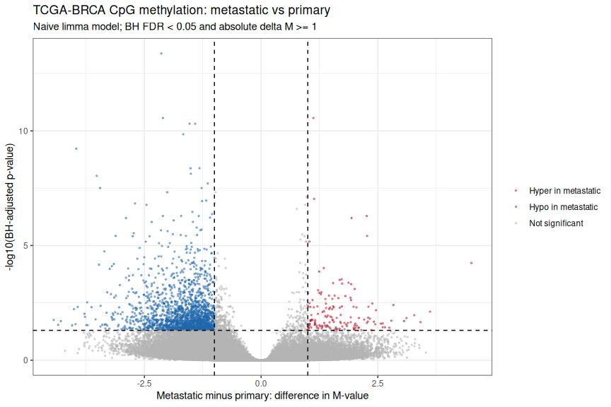

```r
volc <- limma_table
volc$neglog10FDR <- -log10(pmax(volc$adj.P.Val,.Machine$double.xmin))
volc$category <- ifelse(volc$significant & volc$logFC>0,"Hyper in metastatic",
                        ifelse(volc$significant & volc$logFC<0,"Hypo in metastatic","Not significant"))
p1 <- ggplot(volc,aes(logFC,neglog10FDR,color=category))+
  geom_point(alpha=.45,size=.55,na.rm=TRUE)+
  geom_vline(xintercept=c(-1,1),linetype="dashed")+
  geom_hline(yintercept=-log10(.05),linetype="dashed")+
  scale_color_manual(values=c("Hyper in metastatic"="#B2182B","Hypo in metastatic"="#2166AC","Not significant"="grey70"))+
  labs(title="TCGA-BRCA CpG methylation: metastatic vs primary",
       subtitle="Naive limma model; BH FDR < 0.05 and absolute delta M >= 1",
       x="Metastatic minus primary: difference in M-value",y="-log10(BH-adjusted p-value)",color=NULL)+
  theme_bw()
print(p1)
```

```r
ggsave(file.path(output_dir,"brca_methylation_volcano.png"),p1,width=9,height=6,dpi=180)
```

### Part 1 interpretation (automatically populated after execution)

```r
n_up <- sum(limma_table$significant & limma_table$logFC>0)
n_down <- sum(limma_table$significant & limma_table$logFC<0)
cat(sprintf("Across the two TCGA-BRCA specimen categories, the CpG-level model identified **%s CpG sites with higher methylation M-values in metastatic specimens** and **%s with lower M-values**, using BH-adjusted p < 0.05 and an absolute M-value difference of at least 1. ",format(n_up,big.mark=","),format(n_down,big.mark=",")))
```

Across the two TCGA-BRCA specimen categories, the CpG-level model identified **146 CpG sites with higher methylation M-values in metastatic specimens** and **1,787 with lower M-values**, using BH-adjusted p < 0.05 and an absolute M-value difference of at least 1.

```r
cat("These associations indicate that some measured CpG sites differ between the sampled groups, but the plot alone does not show that the differences caused metastasis. ")
```

These associations indicate that some measured CpG sites differ between the sampled groups, but the plot alone does not show that the differences caused metastasis.

```r
cat("In particular, the 'Primary solid Tumor' label does not establish that a patient never developed metastatic disease, and sampling site, tumor purity, clinical confounding, and unequal group sizes can affect the comparison. ")
```

In particular, the ‘Primary solid Tumor’ label does not establish that a patient never developed metastatic disease, and sampling site, tumor purity, clinical confounding, and unequal group sizes can affect the comparison.

```r
cat("The model is unadjusted, so its results should be treated as exploratory rather than patient-level causal or prognostic conclusions.\n")
```

The model is unadjusted, so its results should be treated as exploratory rather than patient-level causal or prognostic conclusions.

# Part 2 — Differential RNA expression and gene intersection

**Do not reuse the Week 7 tumor-versus-normal DESeq results as if they were metastatic-versus-primary.** We refit using RNA counts from Week 7 and **methylation sample metadata** for group assignment. Only exact TCGA sample-level matches (first 16 barcode characters, including sample type and vial) are accepted. If no RNA samples represent both groups, the analysis must stop rather than manufacture a comparison.

```r
rna_counts_path <- file.path(analysis_dir,"brca_rna_count_data.csv")
rna_genes_path <- file.path(analysis_dir,"brca_rna_gene_data.csv")
stopifnot(file.exists(rna_counts_path),file.exists(rna_genes_path))
rna_counts <- read.csv(rna_counts_path,row.names=1,check.names=FALSE)
rna_genes <- read.csv(rna_genes_path,check.names=FALSE)
stopifnot(all(c("gene_id","gene_name") %in% names(rna_genes)))
stopifnot(!anyDuplicated(rownames(rna_counts)))
# TCGA sample-level identifiers: TCGA-XX-XXXX-01A (16 chars).
sample_key <- function(x) substr(as.character(x),1,16)
meth_key <- sample_key(rownames(meth_meta))
stopifnot(all(grepl("^TCGA-",meth_key)))
rna_key <- sample_key(colnames(rna_counts))
stopifnot(all(grepl("^TCGA-",rna_key)))
# Disallow ambiguous methylation annotations or duplicate RNA aliquots for same sample.
unique_m <- !duplicated(meth_key) & !duplicated(meth_key,fromLast=TRUE)
unique_r <- !duplicated(rna_key) & !duplicated(rna_key,fromLast=TRUE)
idx_m <- match(rna_key,meth_key)
matched <- !is.na(idx_m) & unique_r & unique_m[pmax(idx_m,1)]
cat("Unambiguous sample-level RNA/methylation matches:",sum(matched),"\n")
```

```
Unambiguous sample-level RNA/methylation matches: 787
```

```r
matched_counts <- as.matrix(rna_counts[,matched,drop=FALSE])
if (!any(matched)) stop("No unambiguous exact 16-character sample matches between RNA and methylation. A valid metastatic-versus-primary DESeq2 model cannot be inferred from the Week 7 tumor/normal results. Consult the TA about the intended sample matching strategy.")
matched_meta <- meth_meta[idx_m[matched],,drop=FALSE]
rownames(matched_meta) <- colnames(matched_counts)
stopifnot(identical(colnames(matched_counts),rownames(matched_meta)))
print(table(matched_meta$group))
```

```
Primary solid Tumor          Metastatic
                782                   5
```

```r
if (any(table(matched_meta$group)<2)) stop("Cannot fit a metastatic-versus-primary RNA model: fewer than two matched RNA samples in at least one group. Do not substitute Week 7 tumor/normal results. Consult the TA about the intended RNA matching strategy.")
stopifnot(all(is.finite(matched_counts)),all(matched_counts>=0),all(matched_counts==round(matched_counts)))
```

```r
# Required expression filter: total raw count >=20 across retained RNA samples.
matched_counts <- matched_counts[rowSums(matched_counts)>=20,,drop=FALSE]
stopifnot(nrow(matched_counts)>0)
dds <- DESeqDataSetFromMatrix(countData=round(matched_counts),colData=matched_meta,design=~group)
dds <- DESeq(dds)
de_results <- as.data.frame(results(dds,contrast=c("group","Metastatic","Primary solid Tumor")))
de_results$gene_id <- rownames(de_results)
gene_idx <- match(de_results$gene_id,as.character(rna_genes$gene_id))
if (anyNA(gene_idx)) {
  strip_version <- function(x) sub("\\.[0-9]+$", "", as.character(x))
  ref_ids <- strip_version(rna_genes$gene_id)
  stopifnot(!anyDuplicated(ref_ids))
  gene_idx <- match(strip_version(de_results$gene_id),ref_ids)
}
stopifnot(!anyNA(gene_idx))
de_results$gene_name <- as.character(rna_genes$gene_name[gene_idx])
write.csv(de_results,file.path(analysis_dir,"brca_metastatic_vs_primary_DESeq2.csv"),row.names=FALSE)
saveRDS(dds,file.path(analysis_dir,"brca_metastatic_vs_primary_dds.rds"))
cat("Genes tested:",nrow(de_results),"\n")
```

```
Genes tested: 53681
```

```r
print(summary(results(dds,contrast=c("group","Metastatic","Primary solid Tumor"))))
```

```
out of 53680 with nonzero total read count
adjusted p-value < 0.1
LFC > 0 (up)       : 452, 0.84%
LFC < 0 (down)     : 274, 0.51%
outliers [1]       : 1420, 2.6%
low counts [2]     : 15491, 29%
(mean count < 1)
[1] see 'cooksCutoff' argument of ?results
[2] see 'independentFiltering' argument of ?results

NULL
```

## Choose a hypermethylated, downregulated gene

```r
downregulated <- unique(de_results$gene_name[!is.na(de_results$padj) & de_results$padj<.05 & de_results$log2FoldChange<=-1])
hypermethylated <- unique(limma_table$gene_name[
  !is.na(limma_table$gene_name) &
  !is.na(limma_table$adj.P.Val) &
  is.finite(limma_table$logFC) &
  limma_table$adj.P.Val < 0.05 &
  limma_table$logFC > 0
])
interest_genes <- sort(intersect(downregulated,hypermethylated))
cat("Downregulated gene names:",length(downregulated),"\n")
```

```
Downregulated gene names: 220
```

```r
cat("Hypermethylated-associated gene names:",length(hypermethylated),"\n")
```

```
Hypermethylated-associated gene names: 123
```

```r
cat("Intersected candidates:",length(interest_genes),"\n")
```

```
Intersected candidates: 1
```

```r
print(head(interest_genes,25))
```

```
[1] "GRIN2A"
```

```r
if (!length(interest_genes)) stop("No gene passes both criteria; cannot legitimately select a gene for Part 2. Review sample matching and discuss with TA before changing thresholds.")
# Deterministic candidate: strongest RNA adjusted p-value among intersected names.
candidates <- de_results[
  de_results$gene_name %in% interest_genes &
  !is.na(de_results$padj) &
  is.finite(de_results$log2FoldChange) &
  de_results$padj < 0.05 &
  de_results$log2FoldChange <= -1,
  , drop=FALSE
]
candidates <- candidates[order(candidates$padj, -abs(candidates$log2FoldChange)),,drop=FALSE]
GENE <- candidates$gene_name[1]
cat("Selected gene:",GENE,"\n")
```

```
Selected gene: GRIN2A
```

```r
write.csv(candidates,file.path(output_dir,"gene_candidates.csv"),row.names=FALSE)
```

## Gene-specific RNA box plot

Normalized RNA counts are shown for the **matched RNA samples**; the methylation panel uses methylation samples. These are not assumed to be identical cohorts.

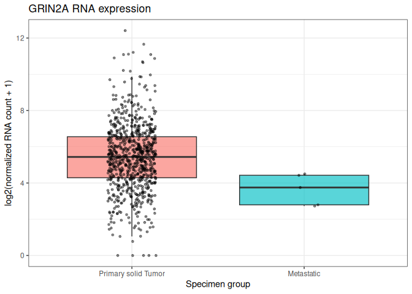

```r
gene_ids <- de_results$gene_id[de_results$gene_name==GENE]
# If several Ensembl IDs have same gene name, use the selected result's gene ID.
gene_id <- candidates$gene_id[1]
stopifnot(gene_id %in% rownames(dds))
normalized <- counts(dds,normalized=TRUE)
plot_rna <- data.frame(group=matched_meta$group,
                       normalized_count=as.numeric(normalized[gene_id,]))
p2 <- ggplot(plot_rna,aes(group,log2(normalized_count+1),fill=group))+
  geom_boxplot(outlier.shape=NA,alpha=.65)+
  geom_jitter(width=.14,height=0,alpha=.45,size=1)+
  theme_bw()+theme(legend.position="none")+
  labs(title=paste(GENE,"RNA expression"),x="Specimen group",y="log2(normalized RNA count + 1)")
print(p2)
```

```r
ggsave(file.path(output_dir,"gene_rna_boxplot.png"),p2,width=7,height=5,dpi=180)
```

## Gene-specific CpG methylation bar plot

Each bar shows the **mean beta value of one CpG probe**, separately by group. Error bars show standard errors; sites are not assumed to be promoters or independent biological replicates.

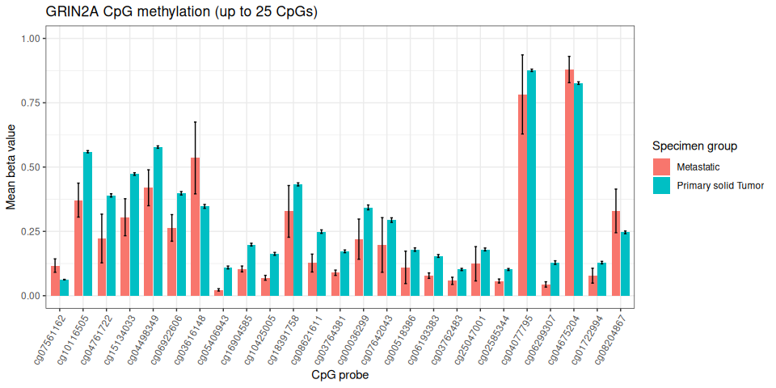

```r
probe_ids <- limma_table$probe_id[!is.na(limma_table$gene_name) & limma_table$gene_name==GENE]
probe_ids <- intersect(probe_ids,rownames(beta))
stopifnot(length(probe_ids)>0)
# Cap at 25 most significant sites for legibility; report this selection explicitly.
ranked <- limma_table[!is.na(limma_table$gene_name) & limma_table$gene_name==GENE,,drop=FALSE]
ranked <- ranked[order(ranked$adj.P.Val),,drop=FALSE]
probe_ids <- head(intersect(ranked$probe_id,rownames(beta)),25)
bar_data <- do.call(rbind,lapply(probe_ids,function(id) {
  do.call(rbind,lapply(levels(grp),function(g) {
    vals <- beta[id,grp==g]
    vals <- vals[is.finite(vals)]
    data.frame(probe=id,group=g,mean_beta=mean(vals),se=if(length(vals)>1) sd(vals)/sqrt(length(vals)) else NA_real_,n=length(vals))
  }))
}))
bar_data$probe <- factor(bar_data$probe,levels=probe_ids)
p3 <- ggplot(bar_data,aes(probe,mean_beta,fill=group))+
  geom_col(position=position_dodge(width=.8),width=.75)+
  geom_errorbar(aes(ymin=pmax(0,mean_beta-se),ymax=pmin(1,mean_beta+se)),
                position=position_dodge(width=.8),width=.22,na.rm=TRUE)+
  coord_cartesian(ylim=c(0,1))+theme_bw()+
  theme(axis.text.x=element_text(angle=60,hjust=1))+
  labs(title=paste(GENE,"CpG methylation (up to 25 CpGs)"),x="CpG probe",y="Mean beta value",fill="Specimen group")
print(p3)
```

```r
ggsave(file.path(output_dir,"gene_methylation_barplot.png"),p3,width=10,height=5,dpi=180)
write.csv(bar_data,file.path(output_dir,"gene_cpg_summary.csv"),row.names=FALSE)
```

### Part 2 interpretation (automatically populated after execution)

```r
gene_row <- candidates[1,,drop=FALSE]
cat(sprintf("The selected candidate **%s** has a metastatic-versus-primary RNA log2 fold change of **%.2f** (BH-adjusted p = %.3g) and at least one associated CpG with a positive metastatic-minus-primary methylation M-value difference meeting the specified thresholds. ",GENE,gene_row$log2FoldChange,gene_row$padj))
```

[output not shown]

```r
cat("The box plot compares normalized RNA abundance in the matched RNA samples, whereas the CpG bar plot displays site-specific mean beta values in the methylation cohort; the two panels need not include identical patients. ")
```

The box plot compares normalized RNA abundance in the matched RNA samples, whereas the CpG bar plot displays site-specific mean beta values in the methylation cohort; the two panels need not include identical patients.

```r
cat("This pattern is compatible with an inverse methylation-expression association but does not demonstrate that methylation represses this gene, because annotated CpGs may lie outside its promoter and other regulatory mechanisms may contribute. ")
```

This pattern is compatible with an inverse methylation-expression association but does not demonstrate that methylation represses this gene, because annotated CpGs may lie outside its promoter and other regulatory mechanisms may contribute.

```r
cat("The groups represent specimen types rather than confirmed lifetime metastatic versus non-metastatic patient histories, and differences in sampling, cohort composition, and tumor purity limit causal interpretation.\n")
```

The groups represent specimen types rather than confirmed lifetime metastatic versus non-metastatic patient histories, and differences in sampling, cohort composition, and tumor purity limit causal interpretation.

## Final checks

```r
expected <- c("brca_methylation_volcano.png","gene_rna_boxplot.png","gene_methylation_barplot.png","gene_candidates.csv","gene_cpg_summary.csv")
stopifnot(all(file.exists(file.path(output_dir,expected))))
stopifnot(file.exists(file.path(analysis_dir,"brca_methylation_metastatic_vs_primary_limma.csv")),
          file.exists(file.path(analysis_dir,"brca_metastatic_vs_primary_DESeq2.csv")),
          file.exists(file.path(analysis_dir,"brca_metastatic_vs_primary_dds.rds")))
stopifnot(identical(colnames(beta),rownames(meth_meta)),
          identical(colnames(matched_counts),rownames(matched_meta)))
cat("All required outputs exist and methylation/RNA sample alignments passed.\n")
```

```
All required outputs exist and methylation/RNA sample alignments passed.
```

# Optional extra credit — NOT automatically completed

For up to three genes, manually capture UCSC Genome Browser screenshots showing CpG islands and protein annotations. Required browser tracks: **GENCODE V49: dense; MANE: pack; UniProt: dense; EPDnewPromoters: dense; CpG Islands: show**. Record the genome assembly, coordinates, and source of each screenshot. For at least one gene, cite a real peer-reviewed research or review article, explain whether it agrees with your results, and discuss disagreement. Do not claim this extra credit without screenshots and a verified reference.